# Homework #3

Ethan Ashby

Due: Feb. 17, 2021

We will need the following libraries for this homework.

```r
library(tidyverse)
library(readxl)
```

The following ensures that the same random choices are made each time the document is knit.

```r
set.seed(12345)
```

Instructions:

1. Be sure to put the file `homework-style.css` in the parent directory of the directory where you have your .Rmd file.
2. Put your solutions between the lines that read `:::: {.solution}` and `::::`.
3. Knit the file to .html.
4. Print the file to .pdf using a browser.
5. Upload your .pdf file to Gradescope.
6. After you upload to Gradescope, you will be asked to mark the pages your problem solutions are on.
7. Be sure to box your work with the `\boxed{put in box}` $\LaTeX$ command.
8. Be sure to give nonintegral answers to four significant digits, except when the form is $a \pm b$. In that case, give $b$ to two significant digits (rounded up) and give $a$ to the same number of *decimal places* as $b$ has.

Suppose $(X, Y) \sim \textsf{Unif}(\{(x, y): x \in [0, 1], 0 \leq y \leq x^2\})$. Find $\mathbb{P}(Y \geq 1 / 2)$.

Let’s illustrate the scenario: the blue area constitutes potential values of $(X, Y)$. The red line corresponds to $Y=1/2$. We are interested in the proportion of curve’s area that lies *above* that red line.

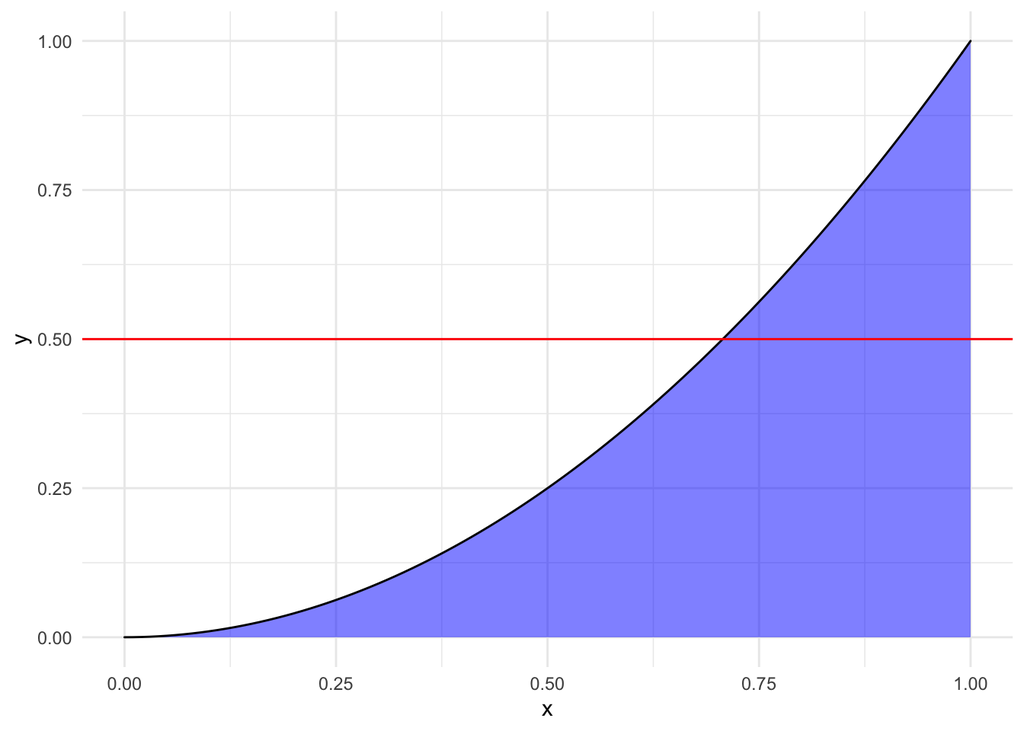

```r
x<-seq(0, 1, 0.01)
y<-x^2

ggplot()+geom_density(data=NULL, aes(x=x, y=y), stat="identity", fill="blue", alpha=0.5)+theme_minimal()+geom_hline(aes(yintercept=0.5), col="red")
```

Let’s solve this problem analytically: First, integrate with respect to $X$ to get the total area underneath the curve: $\int_0^1 x^2 dx =[1/3x^3]^1_0=1/3$.

Second, I’m going to find the area *below* the $Y=0.5$ in a piecewise fashion, by breaking up the area under the line into a portion of the curve and a rectangle: $A_{\textrm{below}}=(\int_0^{\sqrt{2}/2} x^2 dx) + (0.5 \cdot (1-\sqrt{2}/2)) = [\frac{1}{3} x^3]^{\sqrt{2}/2}_0 + 1/2 -\sqrt{2}/4 = \sqrt{2}/12 +1/2 -\sqrt{2}/4 = 0.2643$.

The probability of $Y>=0.5$ will be the complement of the probability of the $Y<0.5$: $1-\frac{(\sqrt{2}/12 +1/2 -\sqrt{2}/4)}{(1/3)}=\boxed{0.2071}$.

To confirm this analytical solution, I’ll check my answer using uniform AR sampling from the unit square.

```r
set.seed(12345)
ar_test <- function() { a <- FALSE
  while (!a) {
  p <- runif(2) # draw uniformly from $[0, 1]^2$
  a <- (p[2]<=p[1]^2) } #tests if y<x^2
  return(p) }

xy_values<-replicate(10^5, ar_test())

#count the number of y values that are greater or equal to 0.5, and divide by total points sampled
length(which(xy_values[2,]>=0.5))/dim(xy_values)[2]
```

```
## [1] 0.20811
```

Thus, my AR estimate for the $\mathbb{P}(Y \geq 1 / 2)=0.2081$. That’s very close!

Suppose that $X \sim \textsf{Unif}(\{1, \ldots, 20\})$ and it is possible to draw an iid sequence $X_1, X_2, \ldots$ from $X$.

1. Write pseudocode to draw samples from $Y \sim \textsf{Unif}(\{1, \ldots, 12\})$ using draws from $X$ and AR.
2. On average, how many draws from $X$ does it take to get a draw from $Y$?

part (a)

```r
draw_unif_12_alg($X$)
1. Draw $X_1$ from $X \sim \unifdist(\{1, \ldots, 20\})$
2. If $X_1 \in {1, \ldots 12}$, return $X_1$ and quit.
3. Else, draw $Y$ according to draw_unif_12_alg($X$), return $Y$ and quit.
```

part (b)

The number of draws $N \sim \textsf{Geo}(p_a)$ where $p_a=\frac{m(A)}{m(B)}$. In this case, $m$ denotes the counting measure, $A=\textsf{Unif}(\{1, \ldots, 12\})$ and $B=\textsf{Unif}(\{1, \ldots, 20\})$, so $p_a=3/5$. According to the geometric distribution $\mathbb{E}{[N]}=\frac{1}{p_a}=\boxed{5/3}$ is the expected number of draws to draw from $Y$.

Find $\text{arg}\,\text{max}_{x > 0} x^{2 / 3} \exp(-x)$.

Let’s solve this analytically. We begin by taking thh derivative of the expression wrt x and set it equal to 0: $\frac{d}{dx}(x^{2/3} \exp(-x))= (x^{2/3} \cdot -\exp(-x)) + (2/3 x^{-1/3} \cdot \exp(-x))=(2/3 x^{-1/3} - x^{2/3}) \exp(-x)$ To solve for argmax/argmin (i.e. x value that produced a maximum/minimum value of the objective function), set the derivative equal to 0:
$$(2/3 x^{-1/3} - x^{2/3}) \exp(-x)=0 \\ (2/3 x^{-1/3} - x^{2/3})=0 \\ 2/3 x^{-1/3}= x^{2/3} \\ 2/3 = x$$
Thus, the function $x^{2 / 3} \exp(-x)$ achieves a critical point at $x=2/3$. To confirm that this is indeed the argmax (rather than the argmin), I include a plot of the original function below, illustrating that $x=2/3$ produces a maximum:

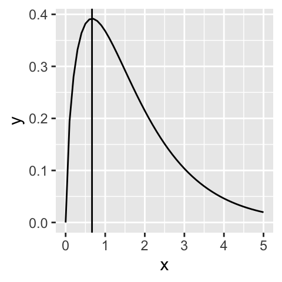

```r
tibble(
  x=seq(0, 5, by=0.1),
  y=x^(2/3) * exp(-x)
) %>% ggplot(aes(x=x, y=y))+geom_line()+geom_vline(aes(xintercept=2/3))
```

So $\text{arg}\,\text{max}_{x > 0} x^{2 / 3} \exp(-x) = \boxed{2/3}$.

To draw $(U, V)$ uniformly from the rectangle $[0, 1] \times [0, 1 / 2]$, use

```r
p <- c(runif(1), runif(1) * 1 / 2)
```

1. Using these draws, write AR code to draw $(X, Y)$ uniformly from the area $\{(x, y):0 \leq x \leq 1, 0 \leq y \leq x^2(1 - x)\}$.
2. Take 1000 draws and estimate the mean value of $X$. Report your answer as $a \pm b$.
3. Use the same draws to estimate the mean value of $Y$. Report your answer as $a \pm b$.
1. My function `ar_p4` does this

```r
set.seed(12345)
#my function ar does this sampling!
ar_p4 <- function() { a <- FALSE
  while (!a) {
  p <- c(runif(1), runif(1) * 1 / 2) # draw uniformly from $[0, 1]^2$
  a <- (p[2]<=p[1]^2*(1-p[1]))} #tests if y<x^2(1-x)
  return(p) }
```

```r
set.seed(12345)
draws<-replicate(1000, ar_p4())
#this returns the mean of all the x's
mean(draws[1,])
```

```
## [1] 0.5983005
```

```r
#this returns the SE estimate
sd(draws[1,])/sqrt(dim(draws)[2])
```

```
## [1] 0.006205082
```

Solution: $\boxed{0.5983 \pm 0.0062}$.

```r
#mean of all the y's
mean(draws[2,])
```

```
## [1] 0.05740229
```

```r
#this returns the SE estimate
sd(draws[2,])/sqrt(dim(draws)[2])
```

```
## [1] 0.001218706
```

Solution: $\boxed{0.0574 \pm 0.0012}$

1. For $\Omega = \{(x, y):x \in [0, 1], 0 \leq y \leq x^2(1 - x)\}$, find the smallest value of $c$ such that $\Omega \subset [0, 1] \times [0, c]$.
2. Using your $c$, write R code to generate from $\{(x, y):x \in [0, 1], 0 \leq y \leq x^2(1 - x)\}$ using AR. Take 1000 draws from your method and estimate the mean value of $x$. Report your answer as $a \pm b$.
1. Finding the smallest value of $c$ such that $\Omega \subset [0, 1] \times [0, c]$ requires us to find the maximum of $\Omega$. We do so via optimization: At its maximum, $y=x^2(1 - x)$ for $x \in [0, 1]$. To solve for the critical values of $y$ over this domain, we take the derivative of $x^2(1 - x)$ and set equal to 0:
   $$\frac{d}{dx} (x^2 - x^3) = 2x-3x^2 =0 \\ x(2-3x)=0 \\ x=0, \frac{2}{3}$$
   Note that the second derivative $\frac{d^2}{dx}=2-6x$ is positive at $x=0$ and negative at $x=2/3$, implying that the curve is concave down, i.e. attains a maximum at $x=2/3$. To find the smallest $c$ needed to upper bound $\Omega$, we find the maximum value $y$ attain by with $x=2/3$. $y$ achieves its maximum in $\Omega$ when equal to $y \leq x^2(1 - x)$, so $c=(2/3)^2*(1-2/3)=\frac{4}{27}$, so $c=\boxed{\frac{4}{27}}$ is the smallest value required to upperbound $\Omega$.

```r
set.seed(12345)
ar_p5 <- function() { a <- FALSE
  while (!a) {
  p <-c(runif(1, min=0, max=1), runif(1, min=0, max=4/27)) # draw uniformly from rectangle
  a <- (p[2]<=p[1]^2*(1-p[1]))} #tests if y<x^2(1-x)
  return(p) }

xys<-replicate(1000, ar_p5())

mean(xys[1,])
```

```
## [1] 0.6024079
```

```r
sd(xys[1,])/sqrt(dim(xys)[2])
```

```
## [1] 0.006266687
```

My estimate of the mean of $x$ for $(x,y) \in \Omega$ is $\boxed{0.6024 \pm 0.0063}$.

1. Given $U \sim \textsf{Unif}([0, 1])$, how would you create a random variable $V \sim \textsf{Unif}([-1, 1])$ as a function of $U$?
2. Using $V_1$ and $V_2$ iid $\textsf{Unif}([-1, 1])$ together with AR, write R code that samples a point $(X, Y)$ uniformly from the entire unit circle.
3. Simulate 1000 points uniformly from the unit circle to estimate the mean distance from the origin. Report your answer as $a \pm b$.
1. Per the lecture notes for 02/10/2020, if $U$ is standard uniform, then $(b-a)U+a \sim \textsf{Unif}([a,b])$. If we desire $V \sim \textsf{Unif}([-1, 1])$, we must set $b=1$ and $a=-1$ yielding $\boxed{V=2U-1}$.

```r
set.seed(12345)

ar_unitcirc<-function(){
  a <- FALSE
  while (!a) {
  V1_V2 <-c(2*runif(1)-1, 2*runif(1)-1) # draw uniformly from [-1, 1]^2
  a <- (sum(V1_V2^2)<=1)} #tests if y<x^2(1-x)
  return(V1_V2) }

#returns one value
ar_unitcirc()
```

```
## [1] 0.4418078 0.7515464
```

The point sampled from the unit circle is $(0.4418, 0.7515)$.

```r
set.seed(12345)
#generate points from inside unit circle
unit_circ_pts<-replicate(1000, ar_unitcirc())

#returns the distances from origin for each xy pair
dists<-apply(unit_circ_pts, MARGIN=2, FUN=function(p){sqrt(sum(p^2))})

#mean dist
mean(dists)
```

```
## [1] 0.6636722
```

```r
#sd dists
sd(dists)/sqrt(length(dists))
```

```
## [1] 0.007532089
```

The mean distance from the origin is $\boxed{0.6636 \pm 0.0075}$.

In R, use `rexp(1, rate = 2)` to generate $T \sim \textsf{Exp}(2)$, which has density
$$f_T(t) = \exp(-2t) \mathbb{I}(t \geq 0).$$

1. Using draws from $T$ together with AR, write R code to generate instances of $W$ with unnormalized density
   $$f_W(w) = e^{-2} \mathbb{I}(w \in [0, 1]) + \exp(-2w) \mathbb{I}(w > 1).$$
2. Using $10^5$ draws from $W$, estimate $\mathbb{E}[W]$. Report your answer as $a \pm b$.

```r
#helper functions for the two densities in question
f_t<-function(t){exp(-2*t)}
f_w<-function(w){ifelse(w<=1, exp(-2), exp(-2*w))}

#ar function that draws from f_w with
ar_draw_fw<-function(){
  a<-FALSE
  while(!a){
    t<-rexp(1,rate=2)
    u<-runif(1)
    a<- (u <= f_w(t)/f_t(t))
  }
  return(t)
}
```

```r
set.seed(12345)
#10^5 draws from this distribution
fw_draws<-replicate(10^5, ar_draw_fw())

#mean draw
mean(fw_draws)
```

```
## [1] 0.8343621
```

```r
#sd draws
sd(fw_draws)/sqrt(length(fw_draws))
```

```
## [1] 0.001908297
```

My estimate of $\mathbb{E}[W]=\boxed{0.8344 \pm 0.0019}$

Consider the functions
$$f_X(s) = s \mathbb{I}(s \in [0, 0.5)) + (1 - s) \mathbb{I}(s \in [0.5, 1]).$$
and
$$g(s) = s (1 - s):$$

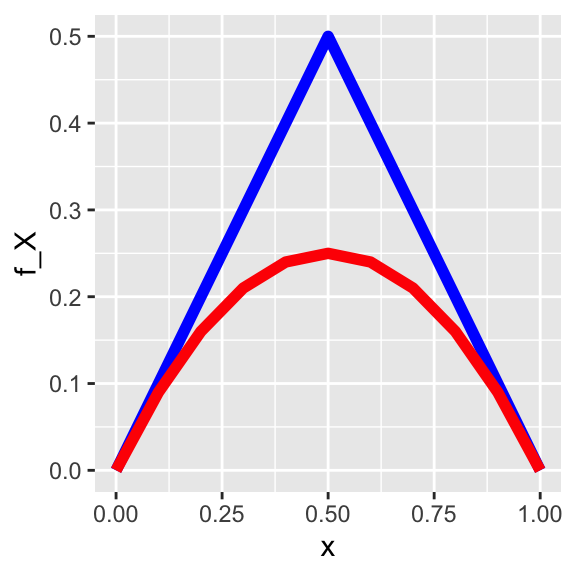

```r
tibble(
  x = seq(0, 1, by = 0.1),
  f_X = x * (x >= 0) * (x < 0.5) + (1 - x) * (x >= 0.5) * (x <= 1),
  g = x * (1 - x)
) %>%
  ggplot() +
    geom_line(aes(x, f_X), lwd = 2, color = "blue") +
    geom_line(aes(x, g), lwd = 2, color = "red")
```

Find $C$ such that $f(x) \leq C g(x)$ for all $x \in [0, 1]$.

Our goal is to find $C$ such that $f(x) \leq C g(x)$. We can also do this by finding $C$ such that $\frac{f(x)}{g(x)} \leq C$.
$$\frac{f(x)}{g(x)}=\frac{1}{1-s} \mathbb{I}(s \in [0, 0.5)) + \frac{1}{s} \mathbb{I}(s \in [0.5, 1]) \leq C$$

Note that the maximum value of $\frac{f(x)}{g(x)}$ can take for $s \in [0.0.5)$ is 1 when $s=0$. The maximum value $\frac{f(x)}{g(x)}$ can take for $s \in [0.5, 1]$ is 2 when $s=0.5$. Thus, the smallest $C$ that ensures that $f(x) \leq C g(x)$ for all $x \in [0, 1]$ is $\boxed{C=2}$.

We can verify this result visually too:

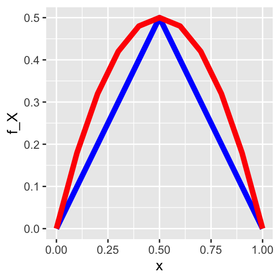

```r
tibble(
  x = seq(0, 1, by = 0.1),
  f_X = x * (x >= 0) * (x < 0.5) + (1 - x) * (x >= 0.5) * (x <= 1),
  g = 2 * x * (1 - x)
) %>%
  ggplot() +
    geom_line(aes(x, f_X), lwd = 2, color = "blue") +
    geom_line(aes(x, g), lwd = 2, color = "red")
```

Looks good!

Consider $X$ with the unnormalized density
$$f_X(s) = s \mathbb{I}(s \in [0, 0.5)) + (1 - s) \mathbb{I}(s \in [0.5, 1]).$$

1. Using draws from $T \sim \textsf{Beta}(2, 2)$, write code to draw from $X$ using AR. Make sure your code uses as few draws from $T$ on average as possible.
2. Estimate $\mathbb{P}(X \leq 1 / 4)$ using 1000 samples. Report your result as $a \pm b$.
1. I propose comparing $f_X$ to $C$ (where $C \sim \frac{\textsf{Beta}(2, 2)}{3}$) because $C$ provides a tighter upperbound on $f_X$ (see green line in figure below), which will minimize the number of AR draws needed to sample from $f_X$. In fact, by considering $C$, the expected number of draws $\mathbb{E}[N]=\frac{1/2}{1/3}=1.5$.

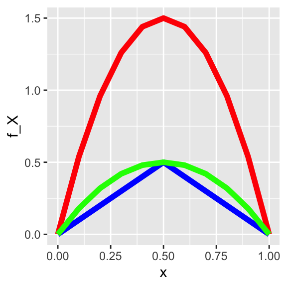

```r
tibble(
  x = seq(0, 1, by = 0.1),
  f_X = x * (x >= 0) * (x < 0.5) + (1 - x) * (x >= 0.5) * (x <= 1),
  g = dbeta(x, 2, 2),
  g_trans= dbeta(x, 2, 2)/3
) %>%
  ggplot() +
    geom_line(aes(x, f_X), lwd = 2, color = "blue") +
    geom_line(aes(x, g), lwd = 2, color = "red") +
    geom_line(aes(x, g_trans), lwd = 2, color = "green")
```

The following code draws from $X$ using AR, while comparing the $f_X$ to $T/3$.

```r
#helper functions
f_x<-function(x){x * (x >= 0) * (x < 0.5) + (1 - x) * (x >= 0.5) * (x <= 1)}

X_ar<-function(){
  a<-FALSE
  while(!a){
    #randomly sample T from beta distribution
    t<-rbeta(1,2,2)
    #get the associated height on the beta distribution for T
    associated_y<-dbeta(t, 2, 2)
    #calculate C, the height on the transformed density with tighter ub
    C=(associated_y/3)
    #draw random uniform to compare to
    u<-runif(1)
    #test if we pass unif threshold with the y/3 as comparison
    a<- (u <= f_x(t)/C)
  }
  return(t)
}
```

```r
set.seed(12345)
samps<-replicate(1000, X_ar())
#estimate prob X<=0.25
mean(samps<=0.25)
```

```
## [1] 0.116
```

```r
#estimate sd of prob
sd(samps<=0.25)/sqrt(length(samps))
```

```
## [1] 0.01013147
```

My probability estimate for $\mathbb{P}[X<0.25]$ is $\boxed{0.116 \pm 0.010}$.

Suppose that $Z \sim \textsf{N}(0, 1)$, and so has density
$$f_Z(z) = \frac{1}{\sqrt{\tau}} \exp(-z^2 / 2).$$
Then for $W = \operatorname{abs}(Z)$, a quick transformation shows that the unnormalized density of $W$ is
$$f_W(w) = \exp(-w^2 / 2)\mathbb{I}(w \geq 0).$$

1. Use draws from $T \sim \textsf{Exp}(1)$ together with AR to write $R$ code to draw from $W$.
2. Use your code to estimate $\mathbb{P}(W \leq 2)$ with 1000 samples. Report your results as $a \pm b$.
1. Step 1, let’s plot these distributions and see what we’re working with

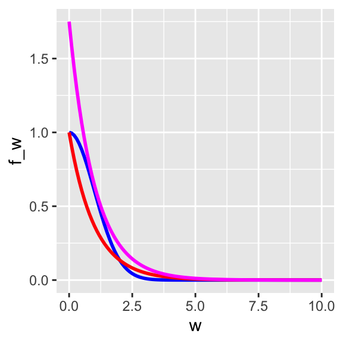

```r
tibble(
  w = seq(0, 10, by = 0.1),
  f_w = exp(-(w^2)/2),
  g = dexp(w, rate=1),
  g_trans=1.75*dexp(w, rate=1)
) %>%
  ggplot() +
    geom_line(aes(w, f_w), lwd = 1, color = "blue") +
    geom_line(aes(w, g), lwd = 1, color = "red") +
    geom_line(aes(w, g_trans), lwd = 1, color = "magenta")
```

I heuristically chose $C \sim 1.75*\textsf{Exp}(x)$ as my upper bound for $f_W$ because it gives a tight UB.

```r
#helper function
f_w<-function(w){exp(-w^2/2)}

ar_w<-function(){
  a<-FALSE
  while(!a){
    #randomly sample from expdist
    w<-rexp(1, rate=1)
    #get the associated height on the beta distribution
    associated_y<-dexp(w, rate=1)
    #calculate C, which upper bounds f_w
    C=1.75*associated_y
    #draw random uniform to compare to
    u<-runif(1)
    #test if we pass unif threshold with the y/3 as comparison
    a<- (u <= f_w(w)/(C))
  }
  w
}
```

```r
set.seed(12345)
ws<-replicate(1000, ar_w())
#prob that W <= 2
mean(ws<=2)
```

```
## [1] 0.959
```

```r
#sd
sd(ws<=2)/sqrt(length(ws))
```

```
## [1] 0.006273624
```

The $\mathbb{P}[W \leq 2]=\boxed{0.9590 \pm 0.0063}$.